# 09 Gráficas II

2024-02-20

## Análisis de datos I (MAT1409)

## 3 Representación Gráfica y Tabular

## Tema. 3.5.1 Gráfica de Pastel: Características

- Se utiliza para representar la **distribución proporcional** de diferentes categorías en un conjunto de datos.
- Cada categoría se muestra como una porción del círculo total.
- Ideal para visualizar **partes de un todo**.
- Puede representar variables continuas en conjunción con variables categóricas.
- Al igual que el histograma, puede respresentar la frecuencia de variables continuas en rangos (clases).

## Tema. 3.5.2 Gráfica de Pastel: Usos

1. **Composición**: Muestra la proporción de cada categoría en un conjunto de datos.
2. **Comparación**: Permite comparar fácilmente las partes entre diferentes grupos.
3. **Énfasis**: Destaca una categoría específica.
4. **Limitaciones**: No es adecuada para representar un número grande de clases.

## Tema. 3.5.3 Gráfica de Pastel con variables Categóricas

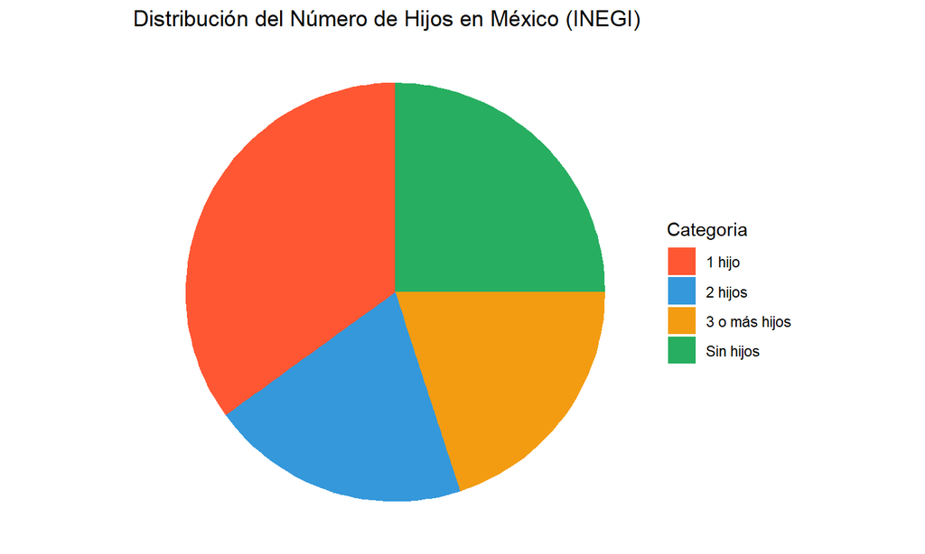

## Tema. 3.5.4 Gráfica de Pastel con variables discretas por Clase (Sturges)

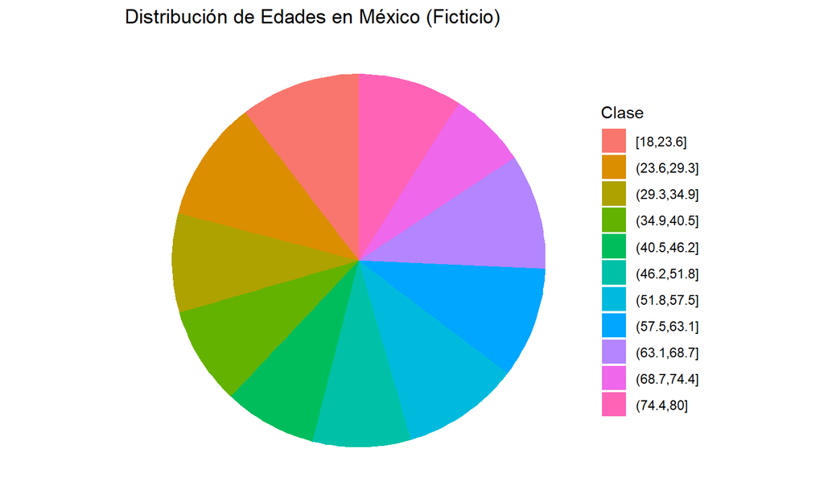

## Tema 3.2.5: Gráfica de Ojiva (Características)

- Utilizada para mostrar cómo se acumulan los datos a lo largo de una variable.
- Representa la **frecuencia acumulada** en función de los valores de la variable.
- Los puntos se conectan mediante líneas rectas, formando una curva ascendente.
- El eje vertical muestra la frecuencia acumulada y el eje horizontal representa los valores de la variable.

## Tema 3.2.6: Gráfica de Ojiva (Usos)

1. **Distribución Acumulada**: Muestra cómo se distribuyen los datos en función de su magnitud.
2. **Identificación de Percentiles**: Permite encontrar percentiles específicos (por ejemplo, el percentil 80%).
3. **Comparación de Distribuciones**: Útil para comparar la acumulación de datos entre diferentes grupos.
4. **Visualización de Tendencias**: Revela patrones de crecimiento o declive en los datos.

## Tema 3.2.7: Tabla de frecuencia Acumulada

- El primer paso es organizar los datos en orden ascendente.
- En la primera columan se ponen los datos (o clases) ordenados sin repetición.
- En la segunda columna se escriben las frecuencias.
- En la tercera columna se suman las frecuencias de la columna 2.
- En la tercera columna se puede estimar el porcentaje acumulado de los datos en cada nivel.

## Tema 3.2.7: Tabla de frecuencia Acumulada (Ejemplo)

| datos_ordenados | Freq | Freq_A | Freq_A_P |
| --- | --- | --- | --- |
| 1 | 9 | 9 | 18 |
| 2 | 8 | 17 | 34 |
| 3 | 11 | 28 | 56 |
| 4 | 6 | 34 | 68 |
| 5 | 9 | 43 | 86 |
| 6 | 7 | 50 | 100 |

## Tema 3.2.8: Gráfica de Ojiva Variable Numérica

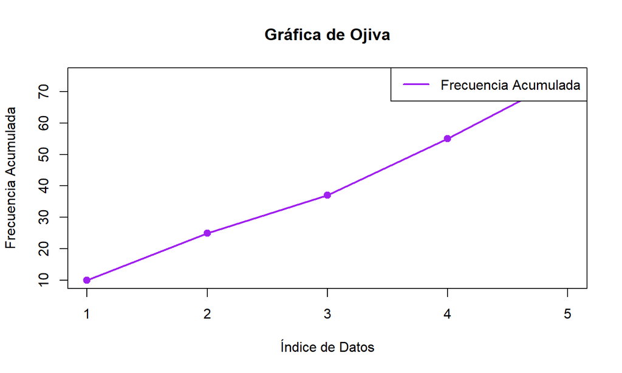

## Tema 3.2.7: Gráfica de Ojiva Variable Contínua

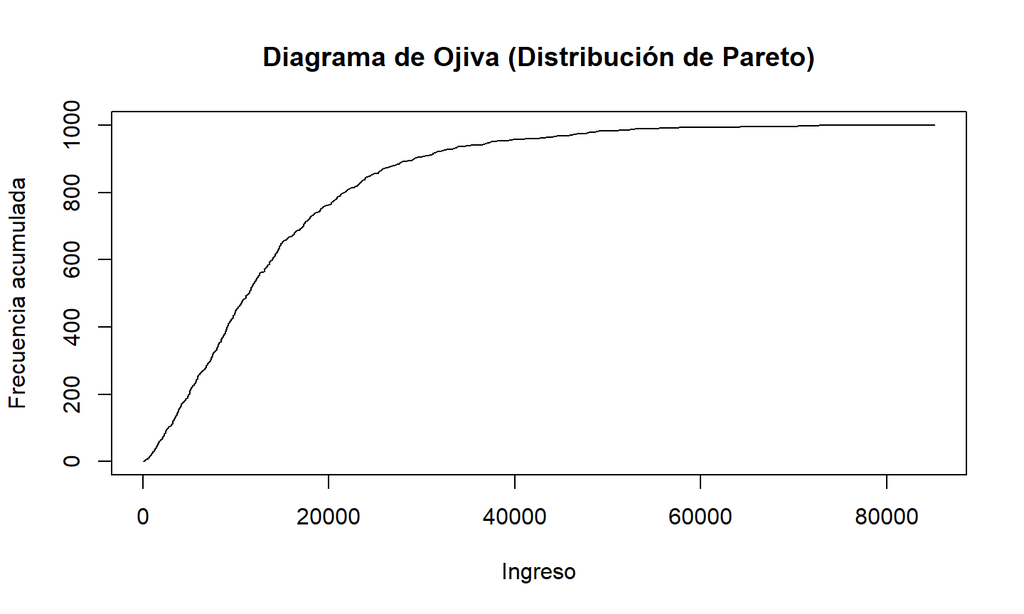

## Revisión

```
## Versión: 22/02/2024
```

## Bibliografía

## Bibliografía

- Dodge, Y. (2008). The concise encyclopedia of statistics. Springer Science & Business Media.
- Business Mathematics.(2023).SBPD https://www.google.com.mx/books/edition/Business_Mathematics/oRLFEAAAQBAJ
- Smith, G. (2015). *Essential statistics, regression, and econometrics.*
- [US GDP](https://data.worldbank.org/indicator/NY.GDP.MKTP.KD.ZG?locations=US)
- [MX Indicator](https://data.worldbank.org/country/mexico)